# Additional file 4: model fit and predictions

We present here the full results from the application of the single-step and multi-step models to data from GRASP. All the posterior samples used for this work are available in `models`. Files bigger than 50 Mb were split into several `.7z` archives for storing on github.

For each model and each antibiotic, we present a figure summarizing different aspects of the model results. Panel (A) shows the model fit; panel (B) is the evolution of treatment usage with time; panel (C) is the model-based projection of NG antimicrobial resistance (using the appropriate EUCAST threshold) until 2030; panel (D) is the projection of NG prevalence if influenced only by resistance levels; and (E) is the evolution of the probability of reaching the 5%, 10% and 20% thresholds. We present results from the single-step model, and when applicable (that is, for all antibiotics except ciprofloxacin), results from the multi-step model.

## Ciprofloxacin

### Single-step model

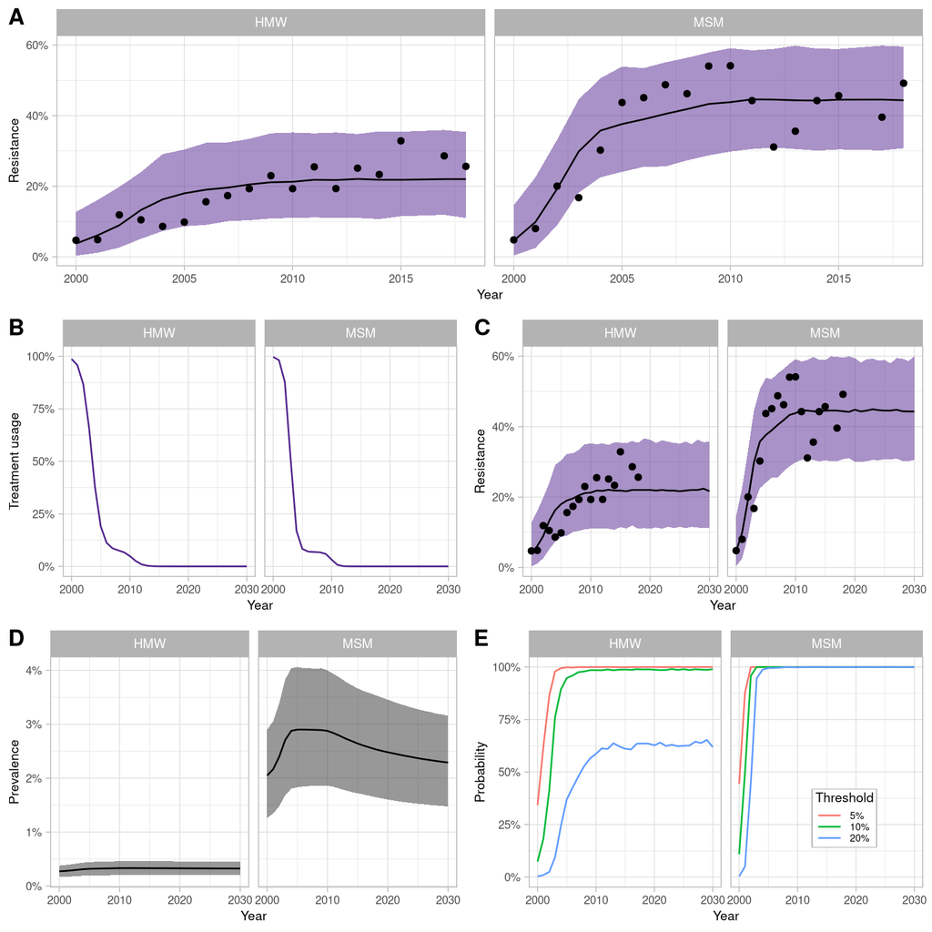

```r
plot_summary(S_binary_grasp_ciprofloxacin,lim=2031,legend.pos=c(.8,.3),colmic = "Purples")
```

### Multi-step model

Not done because of the lack of detail on MIC after 2009 in the data

## Cefixime

### Single-step model

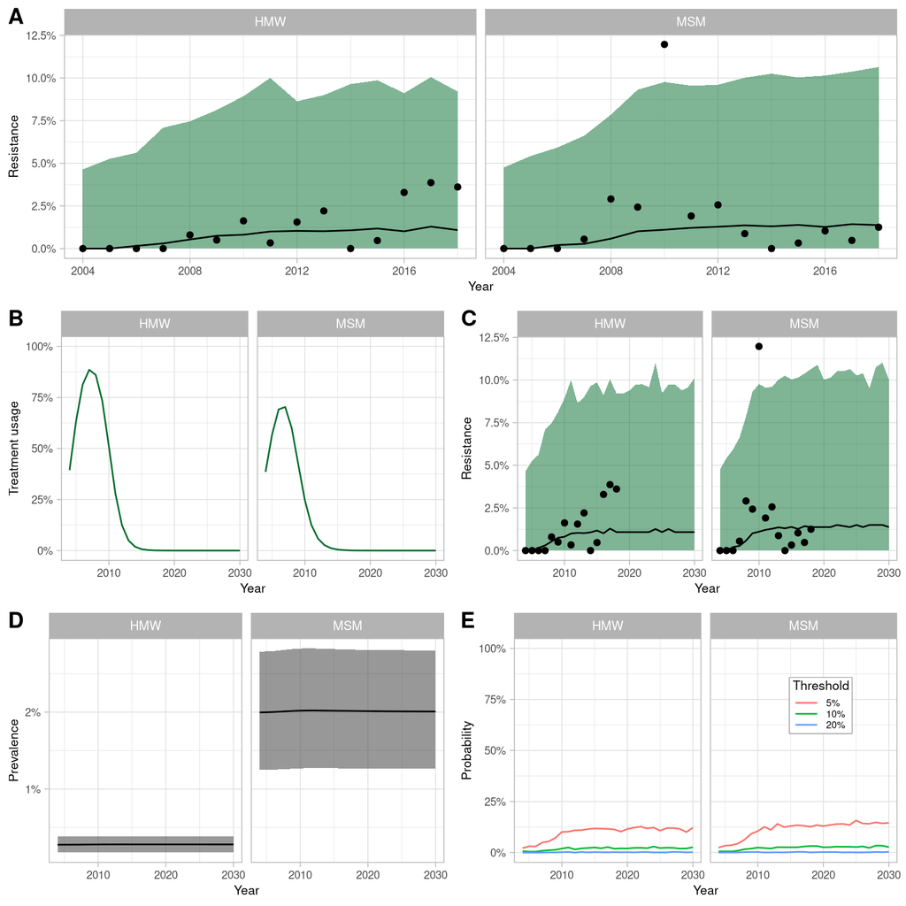

```r
plot_summary(S_binary_grasp_cefixime,lim=2031,legend.pos=c(.8,.7),colmic = "Greens")
```

### Multi-step model

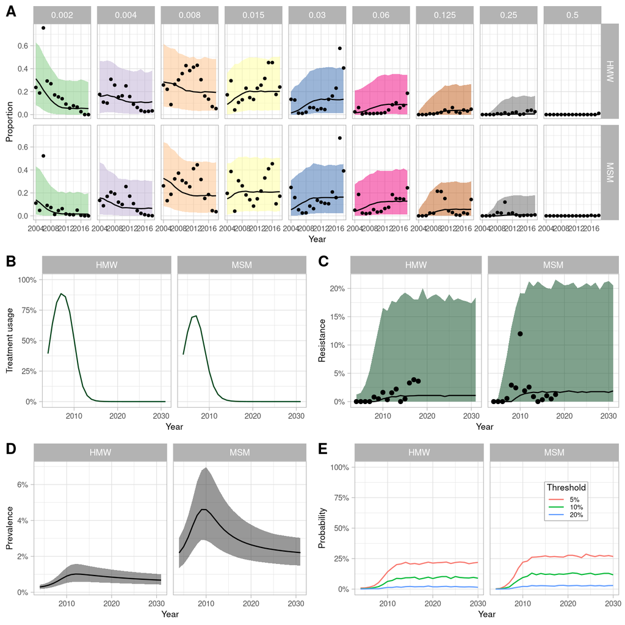

```r
plot_summary2(S_multistep_grasp_cefixime,lim=2031,legend.pos=c(.8,.7),colmic = "Greens")
```

## Azithromycin

### Single-step model

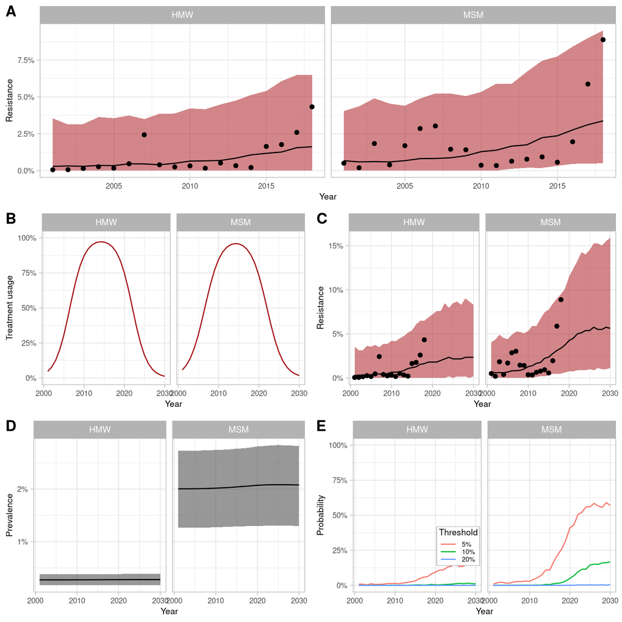

```r
plot_summary(S_binary_grasp_azithro,lim=2031,legend.pos=c(.4,.3),colmic = "Reds")
```

### Multi-step model

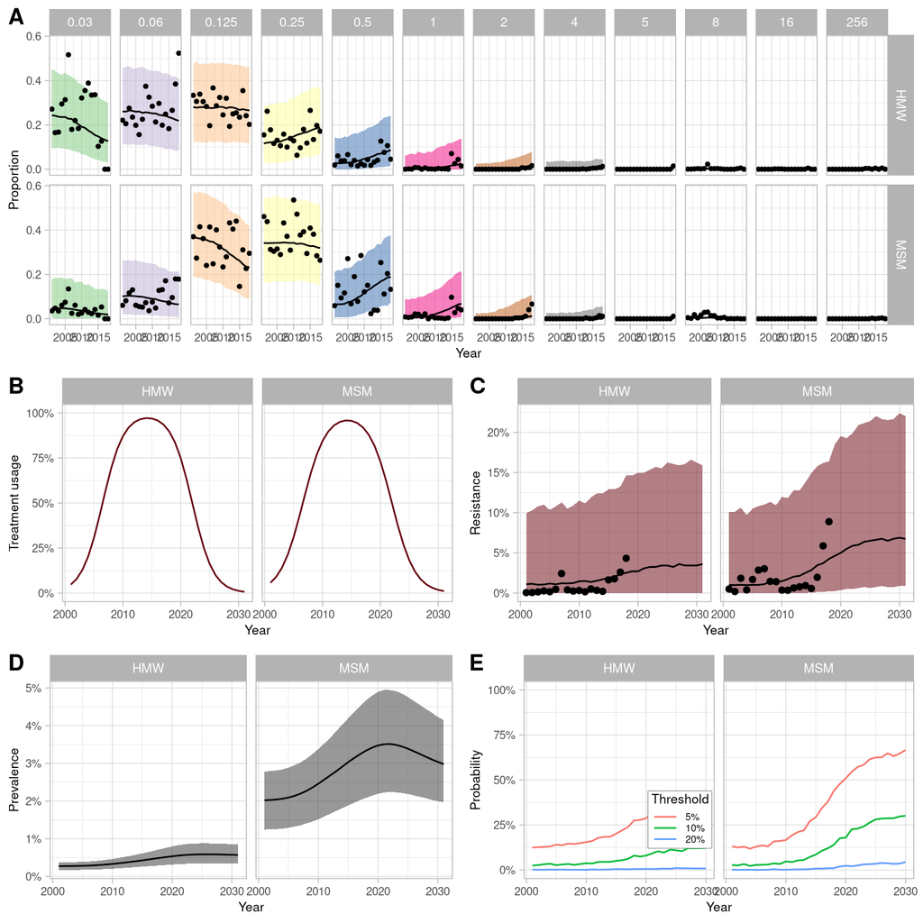

```r
plot_summary2(S_multistep_grasp_azithro,lim=2031,legend.pos=c(.4,.3),colmic = "Reds")
```

## Ceftriaxone

### Single-step model

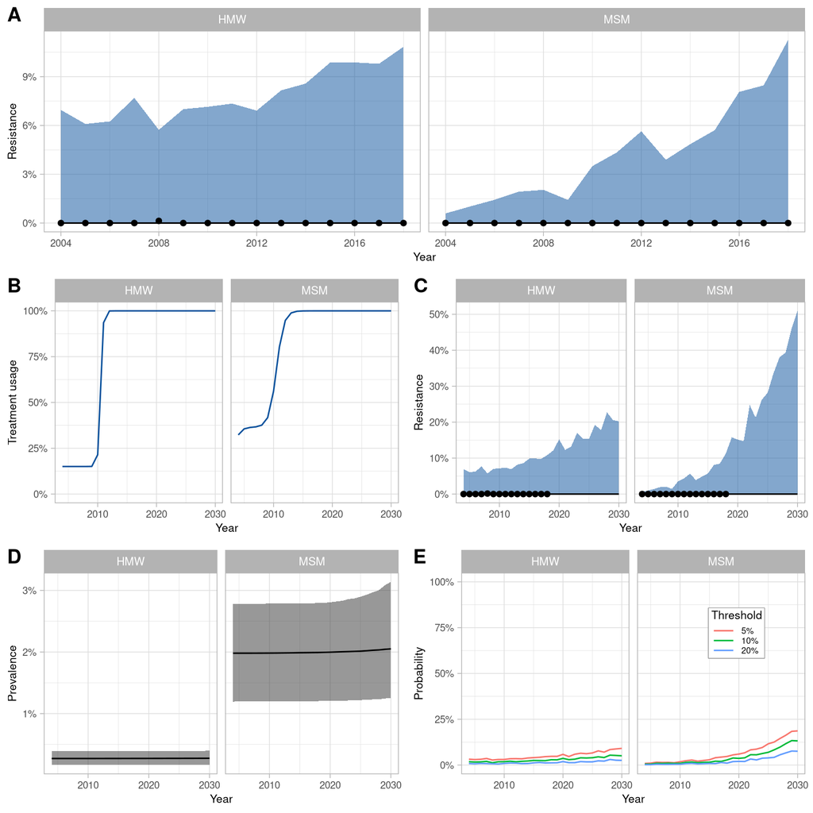

```r
plot_summary(S_binary_grasp_ceftriaxone,lim=2031,legend.pos=c(.8,.7),colmic = "Blues")
```

### Multi-step model

#### With all data from 2004 to 2018

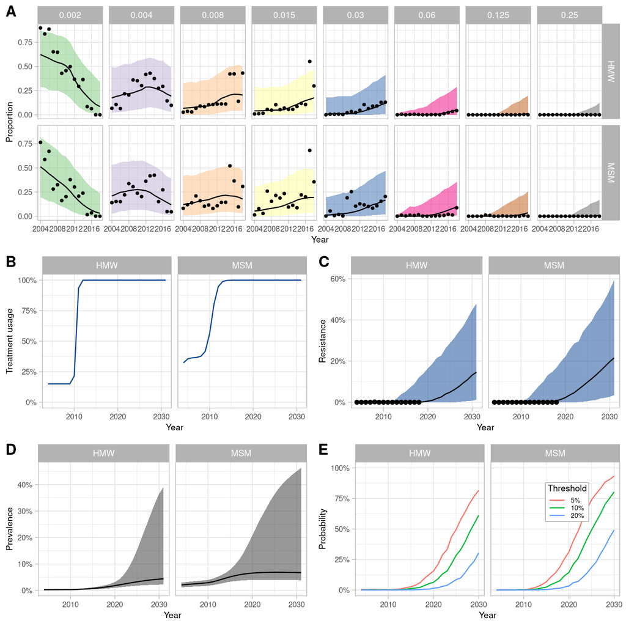

```r
plot_summary2(S_multistep_grasp_ceftriaxone,lim=2031,legend.pos=c(.8,.7),colmic = "Blues")
```

#### Sensitivity analysis removing data from 2009-2010

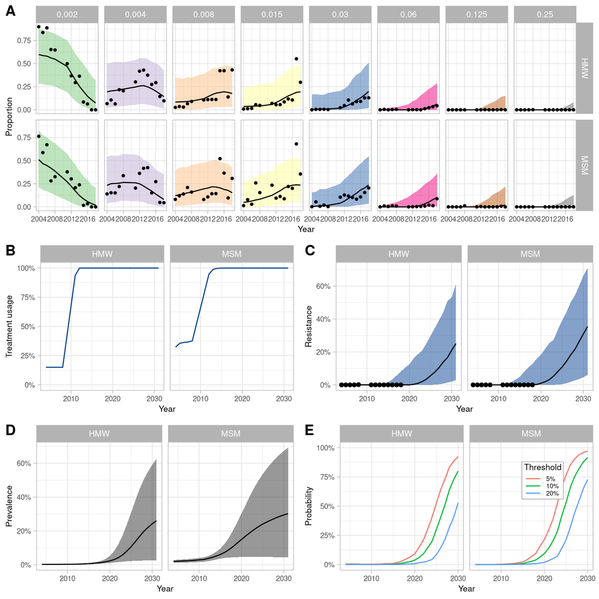

```r
plot_summary2(S_multistep_grasp_ceftriaxone_ss1,lim=2031,legend.pos=c(.8,.7),colmic = "Blues")
```

#### Sensitivity analysis with increasing transmission

##### Yearly increase of $\beta$ by 1.001

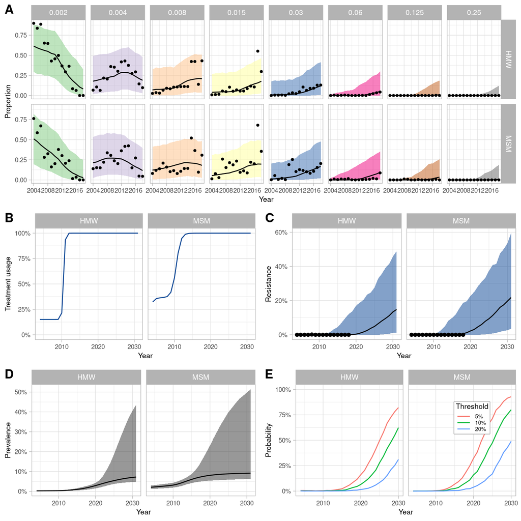

```r
plot_summary2(S_multistep_grasp_ceftriaxone_incprev001,lim=2031,legend.pos=c(.8,.7),colmic = "Blues")
```

##### Yearly increase of $\beta$ by 1.005

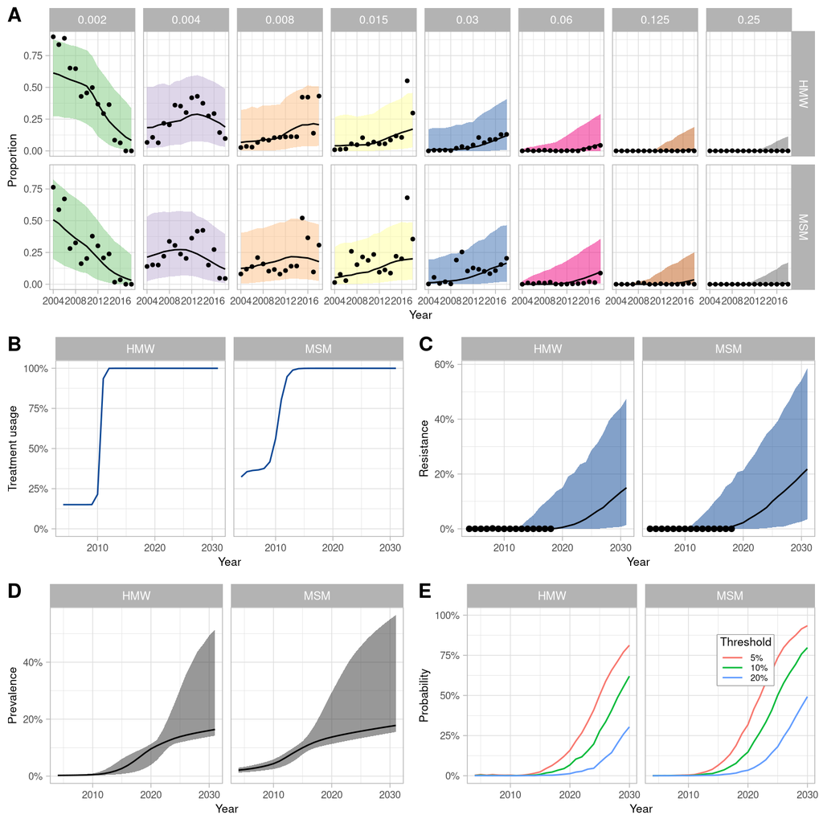

```r
plot_summary2(S_multistep_grasp_ceftriaxone_incprev005,lim=2031,legend.pos=c(.8,.7),colmic = "Blues")
```

##### Yearly increase of $\beta$ by 1.01

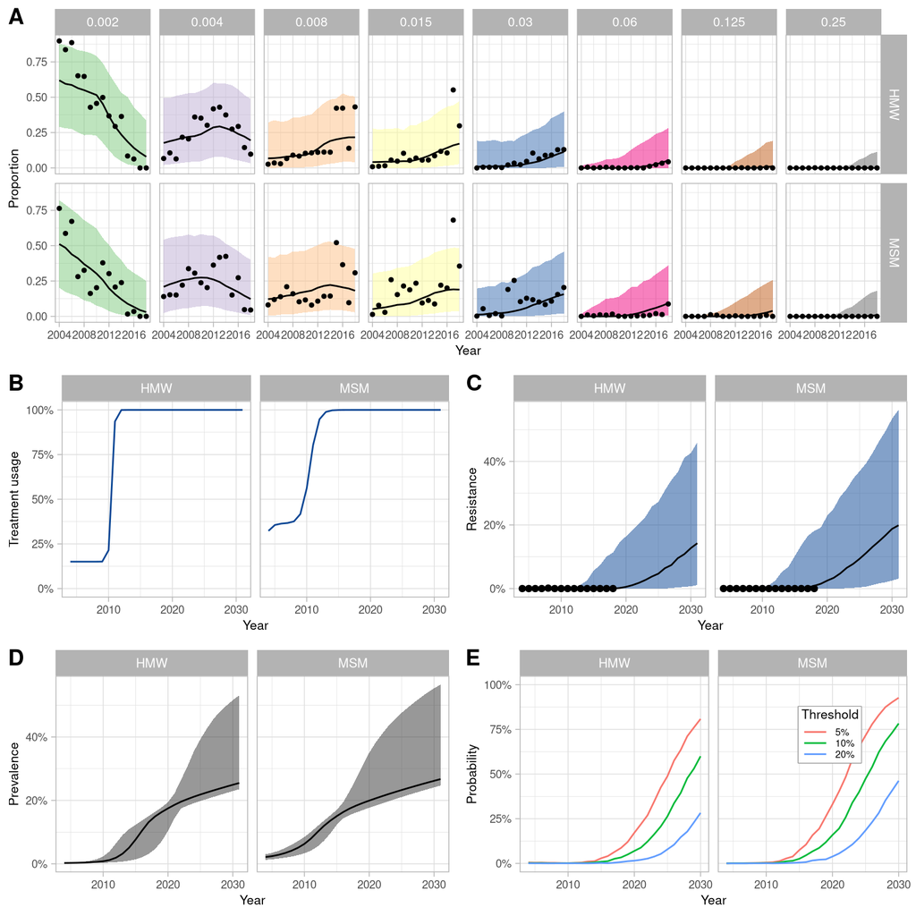

```r
plot_summary2(S_multistep_grasp_ceftriaxone_incprev01,lim=2031,legend.pos=c(.8,.7),colmic = "Blues")
```

```r
# rmarkdown::render("S4_model_fits_predictions.R")
```